# Chap 09:CART

This file introduces classification trees using the `rpart` package. After creating default trees, `cart` is implemented in `caret`. `caret` is basically a machine learning environment which is a wrapper for more than 60 individual r packages and aims to provide a common framework for implementing these algorithms using a unifying syntax. Though `caret` was introduced earlier, here we develop a basic understanding of the syntax and this can be used to fit a variety of machine learning models. Specifically, we will cover the following topics:

1. Use of the `trainControl()` function.
2. Carry out a k-fold cross validation approach (note logistic regression with use the `createDataPartition()` function.)
3. Use of the `preProcess()` function in the training set, if any.
4. Use cross validation to find the best model.
5. Search for a less complex model using various tolerance values.

Note:To install all the libraries needed by `caret` upfront, use the command:

`install.packages("caret", dependencies = c("Depends", "Suggests"))`

```r
library(caret)
library(mlbench)
library(tidyverse)
```

```r
library(skimr)
library(rpart.plot)
library(here)
mower.df <- read_csv("RidingMowers.csv")
str(mower.df)
```

```
## spec_tbl_df [24 x 3] (S3: spec_tbl_df/tbl_df/tbl/data.frame)
##  $ Income   : num [1:24] 60 85.5 64.8 61.5 87 ...
##  $ Lot_Size : num [1:24] 18.4 16.8 21.6 20.8 23.6 19.2 17.6 22.4 20 20.8 ...
##  $ Ownership: chr [1:24] "Owner" "Owner" "Owner" "Owner" ...
##  - attr(*, "spec")=
##   .. cols(
##   ..   Income = col_double(),
##   ..   Lot_Size = col_double(),
##   ..   Ownership = col_character()
##   .. )
##  - attr(*, "problems")=<externalptr>
```

```r
skim(mower.df)
```

Data summary

| Name | mower.df |
| --- | --- |
| Number of rows | 24 |
| Number of columns | 3 |
| _______________________ |  |
| Column type frequency: |  |
| character | 1 |
| numeric | 2 |
| ________________________ |  |
| Group variables | None |

**Variable type: character**

| skim_variable | n_missing | complete_rate | min | max | empty | n_unique | whitespace |
| --- | --- | --- | --- | --- | --- | --- | --- |
| Ownership | 0 | 1 | 5 | 8 | 0 | 2 | 0 |

**Variable type: numeric**

| skim_variable | n_missing | complete_rate | mean | sd | p0 | p25 | p50 | p75 | p100 | hist |
| --- | --- | --- | --- | --- | --- | --- | --- | --- | --- | --- |
| Income | 0 | 1 | 68.44 | 19.79 | 33 | 52.35 | 64.8 | 83.1 | 110.1 | ▃▇▅▆▂ |
| Lot_Size | 0 | 1 | 18.95 | 2.43 | 14 | 17.50 | 19.0 | 20.8 | 23.6 | ▂▇▆▇▃ |

```r
mower.df$Ownership <- factor(mower.df$Ownership,
                                levels = c("Owner", "Nonowner"))

str(mower.df)
```

```
## spec_tbl_df [24 x 3] (S3: spec_tbl_df/tbl_df/tbl/data.frame)
##  $ Income   : num [1:24] 60 85.5 64.8 61.5 87 ...
##  $ Lot_Size : num [1:24] 18.4 16.8 21.6 20.8 23.6 19.2 17.6 22.4 20 20.8 ...
##  $ Ownership: Factor w/ 2 levels "Owner","Nonowner": 1 1 1 1 1 1 1 1 1 1 ...
##  - attr(*, "spec")=
##   .. cols(
##   ..   Income = col_double(),
##   ..   Lot_Size = col_double(),
##   ..   Ownership = col_character()
##   .. )
##  - attr(*, "problems")=<externalptr>
```

Data with 3 features and two levels to classify. Note that by default, for most algorithms in `caret`, the first level in alphabetical term becomes the target group. So always relevel your data so that the first level is the class of interest.

One big question is whether to standardize data before or after the train-test split. Transformations should happen **after** the split and should be done on the training set (set used to fit the model). The standardization parameters should then be applied to the validation set.

The rationale for this is that validation set it totally new and unseen data. So nothing from it should influence model building process.

However, for tree based models, we do not need to standardize the data.

We next split the data in train and test set. Use the `createDataPartition()` function from `caret()` as it will mantain the class distribution in both, training and test sets.

```r
set.seed(107)
trainRows <- createDataPartition(
  y = mower.df$Ownership,
  p = 0.75,
  list = F
)

str(trainRows)
```

```
##  int [1:18, 1] 2 3 5 6 7 9 10 11 12 15 ...
##  - attr(*, "dimnames")=List of 2
##   ..$ : NULL
##   ..$ : chr "Resample1"
```

```r
train.df <- mower.df[trainRows, ]
test.df <- mower.df[-trainRows, ]
nrow(train.df)
```

```
## [1] 18
```

We will create a classification tree with `maxdepth = 2` using `caret`.

In `cacret` we first use the `trainControl()` function to define the type of sampling using the `method=` argument and other model tuning parameters. However, we will first run a tree without any resampling and just run one tree.

```r
cntrl <- trainControl(method = "none")


tree.tune <- expand.grid(maxdepth =2 )

#though expand.grid is an overkill here, good to develop this habit

tree.1 <- train(Ownership ~ .,
                data = mower.df,
                method = "rpart2",
                ##above lists the algorithm to use
                trControl = cntrl,
                ## This specifies the exact model(s) to evaluate
                tuneGrid = tree.tune
                )

#observe the tree
tree.1$finalModel
```

```
## n= 24
##
## node), split, n, loss, yval, (yprob)
##       * denotes terminal node
##
## 1) root 24 12 Owner (0.5000000 0.5000000)
##   2) Income>=59.7 16  5 Owner (0.6875000 0.3125000) *
##   3) Income< 59.7 8  1 Nonowner (0.1250000 0.8750000) *
```

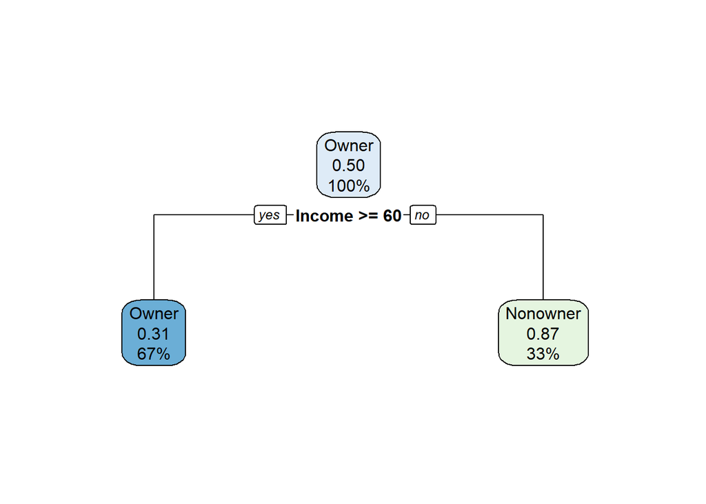

```r
#plot the tree
rpart.plot(tree.1$finalModel)
```

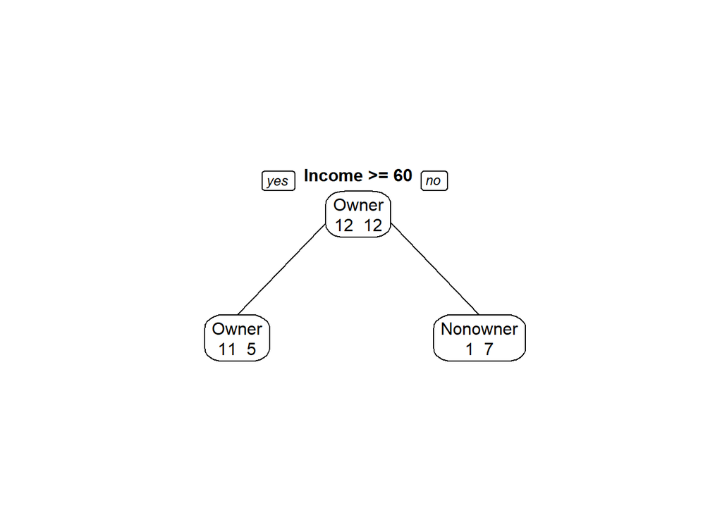

```r
prp(tree.1$finalModel, type =1, extra = 1)
```

Typically, `caret` is used to training and cross-validating our models. Even the default setting in caret does a bootstrap sampling to generate 25 samples and tests 3 values of the the default tunig parameter of the specified method. After that, the tree is pruned by default.

```r
tree.2 <- tree.1 <- train(Ownership ~ .,
                data = mower.df,
                method = "rpart")
tree.2
```

```
## CART
##
## 24 samples
##  2 predictor
##  2 classes: 'Owner', 'Nonowner'
##
## No pre-processing
## Resampling: Bootstrapped (25 reps)
## Summary of sample sizes: 24, 24, 24, 24, 24, 24, ...
## Resampling results across tuning parameters:
##
##   cp    Accuracy   Kappa
##   0.00  0.5982063  0.18327112
##   0.25  0.5982063  0.18327112
##   0.50  0.5025556  0.07150732
##
## Accuracy was used to select the optimal model using the largest value.
## The final value used for the model was cp = 0.25.
```

```r
prp(tree.2$finalModel, type =1, extra = 1)


tree.3 <- tree.1 <- train(Ownership ~ .,
                data = mower.df,
                method = "rpart2")
```

[output not shown]

```
## note: only 1 possible values of the max tree depth from the initial fit.
##  Truncating the grid to 1 .
```

```r
tree.3
```

```
## CART
##
## 24 samples
##  2 predictor
##  2 classes: 'Owner', 'Nonowner'
##
## No pre-processing
## Resampling: Bootstrapped (25 reps)
## Summary of sample sizes: 24, 24, 24, 24, 24, 24, ...
## Resampling results:
##
##   Accuracy   Kappa
##   0.6259192  0.2183343
##
## Tuning parameter 'maxdepth' was held constant at a value of 1
```

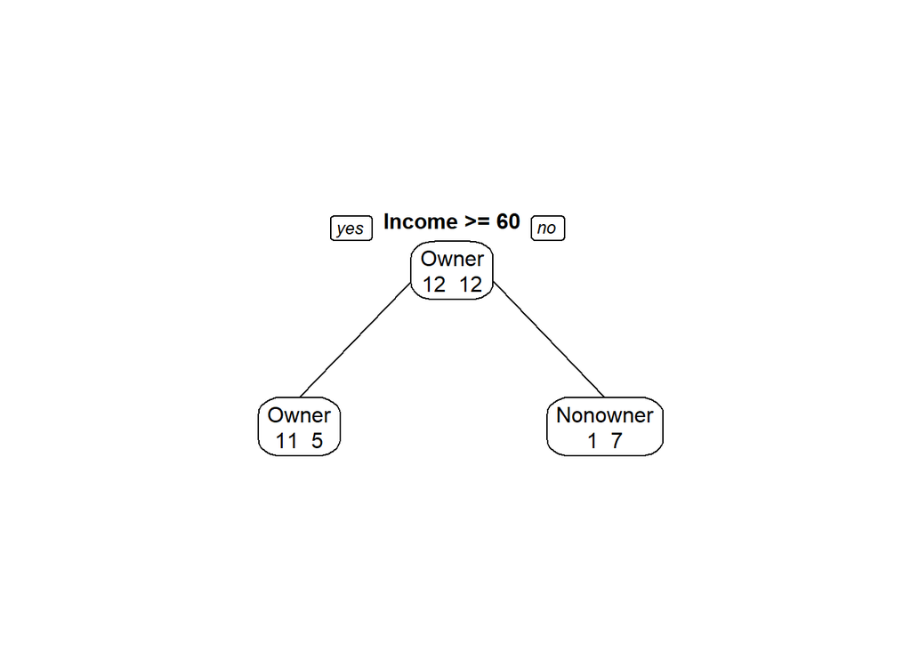

```r
prp(tree.3$finalModel, type =1, extra = 1)
```

Now, let us run the full tree. Note that `caret` will not run the full tree as the default is to prune the tree. Thus, the full tree will be run by the `rpart` package and the tunig values will be provided in the `rpart.control()` function.

```r
tree4.cntrl <- rpart.control(cp = 0,
                          minsplit = 1)

tree.4 <- rpart(Ownership ~ .,
                data = mower.df,
                control = tree4.cntrl,
                method = "class" )

#observe the tree
tree.4
```

```
## n= 24
##
## node), split, n, loss, yval, (yprob)
##       * denotes terminal node
##
##  1) root 24 12 Owner (0.5000000 0.5000000)
##    2) Income>=59.7 16  5 Owner (0.6875000 0.3125000)
##      4) Lot_Size>=19.8 7  0 Owner (1.0000000 0.0000000) *
##      5) Lot_Size< 19.8 9  4 Nonowner (0.4444444 0.5555556)
##       10) Income>=84.75 3  0 Owner (1.0000000 0.0000000) *
##       11) Income< 84.75 6  1 Nonowner (0.1666667 0.8333333)
##         22) Income< 61.5 1  0 Owner (1.0000000 0.0000000) *
##         23) Income>=61.5 5  0 Nonowner (0.0000000 1.0000000) *
##    3) Income< 59.7 8  1 Nonowner (0.1250000 0.8750000)
##      6) Lot_Size>=21.4 1  0 Owner (1.0000000 0.0000000) *
##      7) Lot_Size< 21.4 7  0 Nonowner (0.0000000 1.0000000) *
```

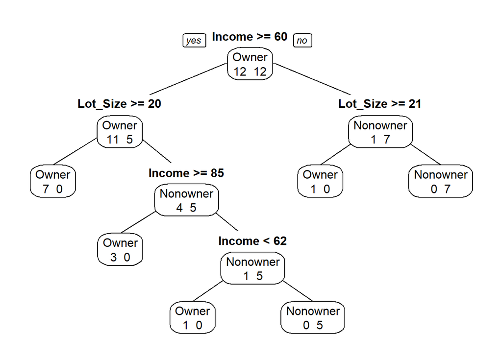

```r
#plot the tree

prp(tree.4, type =1, extra = 1)
```

There is workaround in `caret` whereby we can supply the default tuning parameters from the method which is called.

```r
 tree.5 <- train(Ownership ~ .,
                data = mower.df,
                method = "rpart",
                control = tree4.cntrl # Note this step
                )
tree.5
```

```
## CART
##
## 24 samples
##  2 predictor
##  2 classes: 'Owner', 'Nonowner'
##
## No pre-processing
## Resampling: Bootstrapped (25 reps)
## Summary of sample sizes: 24, 24, 24, 24, 24, 24, ...
## Resampling results across tuning parameters:
##
##   cp    Accuracy   Kappa
##   0.00  0.6517100  0.3013745
##   0.25  0.5500750  0.1196913
##   0.50  0.5027417  0.1023725
##
## Accuracy was used to select the optimal model using the largest value.
## The final value used for the model was cp = 0.
```

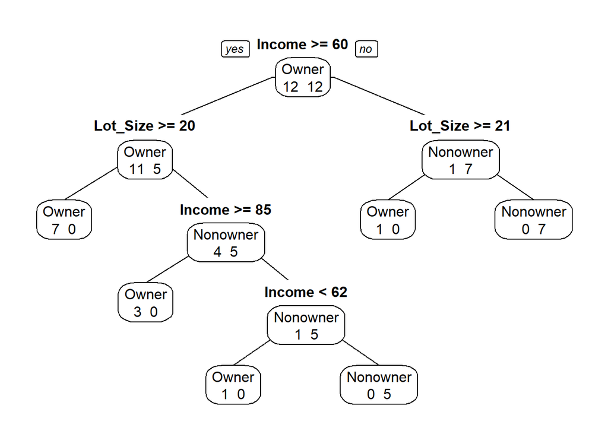

```r
prp(tree.5$finalModel, type =1, extra = 1)
```

To classify a new record, we can drop it down the tree till we arrive at a decision node. We see that this tree has perfectly classified all the existing records. In classifying on new data however, this model may not do as well due to overfitting. Next we address the issue of overfitting and also work with a more realistic problem.

###Acceptance of Personal Loan

Universal Bank wants to analyze what factors make a customer more likely to accept a personal loan.

```r
bank.df <- read.csv("UniversalBank.csv")
skim(bank.df)
```

Data summary

| Name | bank.df |
| --- | --- |
| Number of rows | 5000 |
| Number of columns | 14 |
| _______________________ |  |
| Column type frequency: |  |
| numeric | 14 |
| ________________________ |  |
| Group variables | None |

**Variable type: numeric**

| skim_variable | n_missing | complete_rate | mean | sd | p0 | p25 | p50 | p75 | p100 | hist |
| --- | --- | --- | --- | --- | --- | --- | --- | --- | --- | --- |
| ID | 0 | 1 | 2500.50 | 1443.52 | 1 | 1250.75 | 2500.5 | 3750.25 | 5000 | ▇▇▇▇▇ |
| Age | 0 | 1 | 45.34 | 11.46 | 23 | 35.00 | 45.0 | 55.00 | 67 | ▅▇▇▇▆ |
| Experience | 0 | 1 | 20.10 | 11.47 | -3 | 10.00 | 20.0 | 30.00 | 43 | ▅▇▇▇▅ |
| Income | 0 | 1 | 73.77 | 46.03 | 8 | 39.00 | 64.0 | 98.00 | 224 | ▇▇▃▂▁ |
| ZIP.Code | 0 | 1 | 93152.50 | 2121.85 | 9307 | 91911.00 | 93437.0 | 94608.00 | 96651 | ▁▁▁▁▇ |
| Family | 0 | 1 | 2.40 | 1.15 | 1 | 1.00 | 2.0 | 3.00 | 4 | ▇▇▁▆▆ |
| CCAvg | 0 | 1 | 1.94 | 1.75 | 0 | 0.70 | 1.5 | 2.50 | 10 | ▇▃▁▁▁ |
| Education | 0 | 1 | 1.88 | 0.84 | 1 | 1.00 | 2.0 | 3.00 | 3 | ▇▁▆▁▆ |
| Mortgage | 0 | 1 | 56.50 | 101.71 | 0 | 0.00 | 0.0 | 101.00 | 635 | ▇▂▁▁▁ |
| Personal.Loan | 0 | 1 | 0.10 | 0.29 | 0 | 0.00 | 0.0 | 0.00 | 1 | ▇▁▁▁▁ |
| Securities.Account | 0 | 1 | 0.10 | 0.31 | 0 | 0.00 | 0.0 | 0.00 | 1 | ▇▁▁▁▁ |
| CD.Account | 0 | 1 | 0.06 | 0.24 | 0 | 0.00 | 0.0 | 0.00 | 1 | ▇▁▁▁▁ |
| Online | 0 | 1 | 0.60 | 0.49 | 0 | 0.00 | 1.0 | 1.00 | 1 | ▆▁▁▁▇ |
| CreditCard | 0 | 1 | 0.29 | 0.46 | 0 | 0.00 | 0.0 | 1.00 | 1 | ▇▁▁▁▃ |

```r
#Let's remove ID and Zip

bank.df <- bank.df %>%
  select(-c(1,5))

# convert loan application to factor with 1 as the target class

bank.df$Personal.Loan <- factor(as.character(bank.df$Personal.Loan),
                                  levels = c("1", "0"),
                                  labels = c("Yes", "No"))

bank.df <- bank.df %>%
  rename(Loan = Personal.Loan )
str(bank.df)
```

```
## 'data.frame':    5000 obs. of  12 variables:
##  $ Age               : int  25 45 39 35 35 37 53 50 35 34 ...
##  $ Experience        : int  1 19 15 9 8 13 27 24 10 9 ...
##  $ Income            : int  49 34 11 100 45 29 72 22 81 180 ...
##  $ Family            : int  4 3 1 1 4 4 2 1 3 1 ...
##  $ CCAvg             : num  1.6 1.5 1 2.7 1 0.4 1.5 0.3 0.6 8.9 ...
##  $ Education         : int  1 1 1 2 2 2 2 3 2 3 ...
##  $ Mortgage          : int  0 0 0 0 0 155 0 0 104 0 ...
##  $ Loan              : Factor w/ 2 levels "Yes","No": 2 2 2 2 2 2 2 2 2 1 ...
##  $ Securities.Account: int  1 1 0 0 0 0 0 0 0 0 ...
##  $ CD.Account        : int  0 0 0 0 0 0 0 0 0 0 ...
##  $ Online            : int  0 0 0 0 0 1 1 0 1 0 ...
##  $ CreditCard        : int  0 0 0 0 1 0 0 1 0 0 ...
```

```r
#Do a 60-40 split

table(bank.df$Loan)/nrow(bank.df) # check to proportion of Loan Acceptances
```

```
##
##   Yes    No
## 0.096 0.904
```

```r
#createDataPartition will try to maintain this ratio in training and valid
set.seed(1)
indTrain <- createDataPartition(bank.df$Loan, p = 0.6, times = 1, list = F)

train.df <- bank.df[indTrain,]

table(train.df$Loan)/nrow(train.df)
```

```
##
##   Yes    No
## 0.096 0.904
```

```r
table(train.df$Loan)
```

```
##
##  Yes   No
##  288 2712
```

```r
valid.df <- bank.df[-indTrain,]
table(valid.df$Loan)/nrow(valid.df)
```

```
##
##   Yes    No
## 0.096 0.904
```

```r
# thus, for unbalanced data, the above approach is desirable
```

Let us start by running the full tree to this data on the training set.

The `rpart()` method has a control function, `rpart.control()` with some preset default values. These values are passed on to the `rpart` call.

Tuning is generally done by changing `minsplit`, `cp` and `maxdepth`.

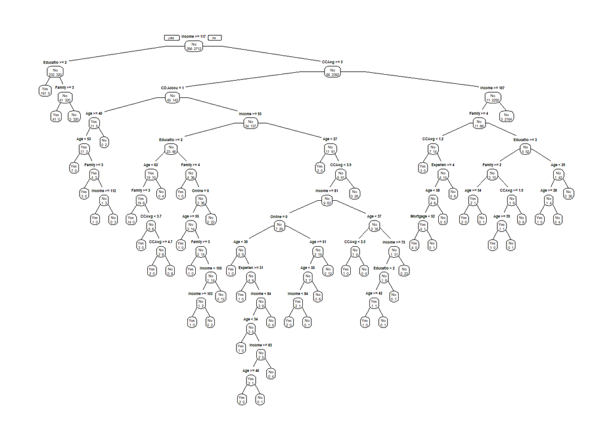

```r
cntrl <- rpart.control(minsplit = 1,
                       cp = 0)
full.tree.rpart <- rpart(Loan ~ ., data = train.df,
                         method = "class",
                         control = cntrl)

prp(full.tree.rpart, type = 1, extra = 1)
```

As we can see, the above tree is pretty nonsensical. It will do a good job of classifying all our training records but not do a good job of classifying new records. `caret` will not even allow the tree to go this deep.

```r
cntrl <- trainControl(method = "none")
tree.1.train <- train(Loan ~ .,
                data = train.df,
                method = "rpart",
                control = rpart.control(cp = 0,
                          minsplit = 1) )# Note this step

tree.1.train$finalModel
```

```
## n= 3000
##
## node), split, n, loss, yval, (yprob)
##       * denotes terminal node
##
##  1) root 3000 288 No (0.09600000 0.90400000)
##    2) Income>=116.5 552 232 No (0.42028986 0.57971014)
##      4) Education>=1.5 191   0 Yes (1.00000000 0.00000000) *
##      5) Education< 1.5 361  41 No (0.11357341 0.88642659)
##       10) Family>=2.5 41   0 Yes (1.00000000 0.00000000) *
##       11) Family< 2.5 320   0 No (0.00000000 1.00000000) *
##    3) Income< 116.5 2448  56 No (0.02287582 0.97712418) *
```

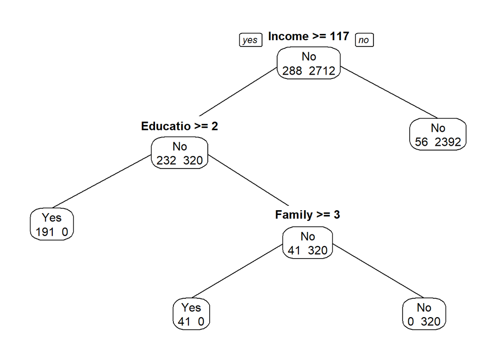

```r
prp(tree.1.train$finalModel, type =1, extra = 1)
```

```
 control = rpart.control(cp = 0,
                          minsplit = 1) )
```

The crazy size of the tree can be addressed by pruning the tree. The default tree approach in `caret` is to prune the tree based on `Cp`, the complexity parameter. Basically, if accuracy does not improve beyond a certain threshold determined by Cp, the split at that node will not take place. Let us first run a basic pruned tree without any further parameter tuning. Below, we search for the Cp that provides the most accuracy in the training set.

```r
cntrl <- trainControl(method = "none")
tree.2.train <- train(Loan ~ .,
                data = train.df,
                method = "rpart",
                tuneLength = 30)


tree.2.train$finalModel
```

```
## n= 3000
##
## node), split, n, loss, yval, (yprob)
##       * denotes terminal node
##
##  1) root 3000 288 No (0.09600000 0.90400000)
##    2) Income>=116.5 552 232 No (0.42028986 0.57971014)
##      4) Education>=1.5 191   0 Yes (1.00000000 0.00000000) *
##      5) Education< 1.5 361  41 No (0.11357341 0.88642659)
##       10) Family>=2.5 41   0 Yes (1.00000000 0.00000000) *
##       11) Family< 2.5 320   0 No (0.00000000 1.00000000) *
##    3) Income< 116.5 2448  56 No (0.02287582 0.97712418) *
```

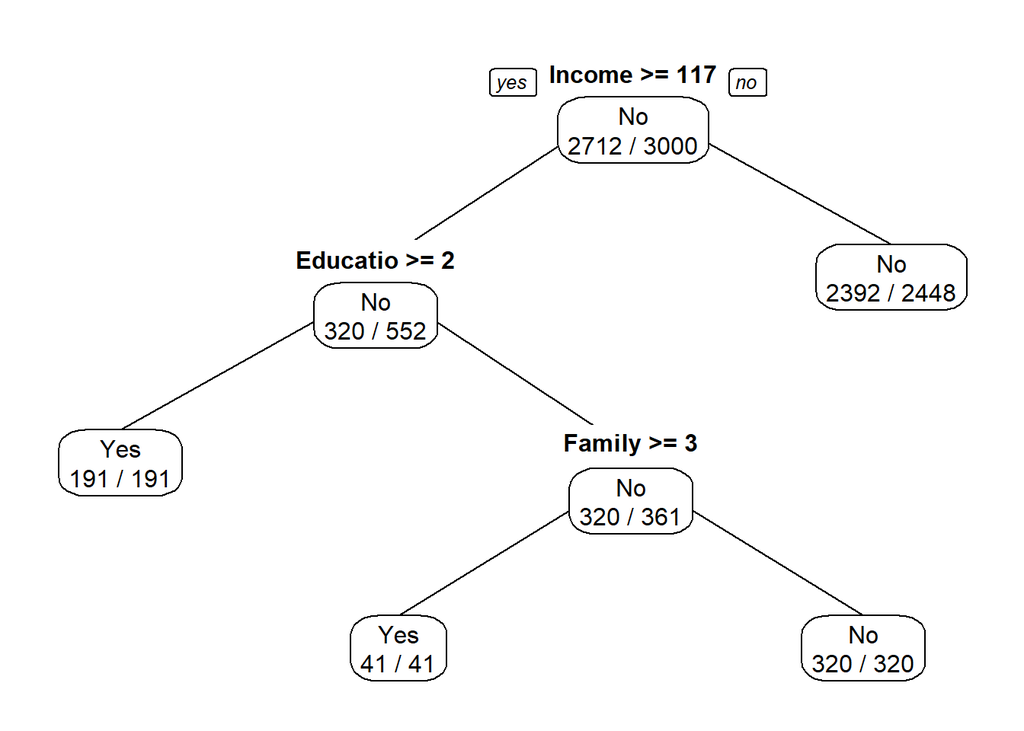

```r
prp(tree.2.train$finalModel, type =1, extra = 2)
```

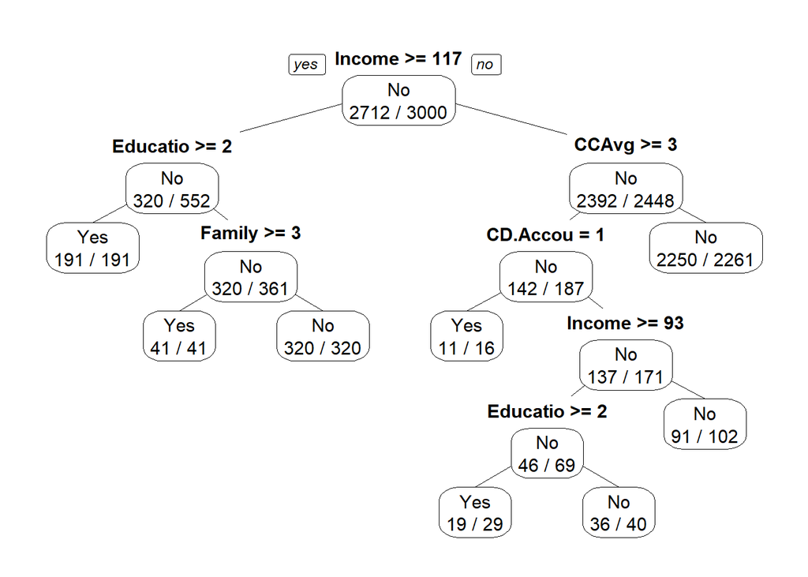

```r
# Default tree from rpart
def.tree.rpart <- rpart(Loan ~ ., data = train.df, method = "class")
prp(def.tree.rpart, type =1, extra = 2 )
```

```r
pred.Loan.full <- predict(full.tree.rpart, data = train.df, type = "class")

confusionMatrix(pred.Loan.full, train.df$Loan)
```

```
## Confusion Matrix and Statistics
##
##           Reference
## Prediction  Yes   No
##        Yes  288    0
##        No     0 2712
##
##                Accuracy : 1
##                  95% CI : (0.9988, 1)
##     No Information Rate : 0.904
##     P-Value [Acc > NIR] : < 2.2e-16
##
##                   Kappa : 1
##
##  Mcnemar's Test P-Value : NA
##
##             Sensitivity : 1.000
##             Specificity : 1.000
##          Pos Pred Value : 1.000
##          Neg Pred Value : 1.000
##              Prevalence : 0.096
##          Detection Rate : 0.096
##    Detection Prevalence : 0.096
##       Balanced Accuracy : 1.000
##
##        'Positive' Class : Yes
##
```

```r
#Now on the validation set
pred.Loan.full.val <- predict(full.tree.rpart, newdata = valid.df, type = "class")

confusionMatrix(pred.Loan.full.val, valid.df$Loan)
```

```
## Confusion Matrix and Statistics
##
##           Reference
## Prediction  Yes   No
##        Yes  172   14
##        No    20 1794
##
##                Accuracy : 0.983
##                  95% CI : (0.9763, 0.9882)
##     No Information Rate : 0.904
##     P-Value [Acc > NIR] : <2e-16
##
##                   Kappa : 0.9007
##
##  Mcnemar's Test P-Value : 0.3912
##
##             Sensitivity : 0.8958
##             Specificity : 0.9923
##          Pos Pred Value : 0.9247
##          Neg Pred Value : 0.9890
##              Prevalence : 0.0960
##          Detection Rate : 0.0860
##    Detection Prevalence : 0.0930
##       Balanced Accuracy : 0.9440
##
##        'Positive' Class : Yes
##
```

```r
# Valid confusion matrix for the default tree
pred.Loan.def1.val <- predict(def.tree.rpart , newdata = valid.df, type = "class")
confusionMatrix(pred.Loan.def1.val, valid.df$Loan)
```

```
## Confusion Matrix and Statistics
##
##           Reference
## Prediction  Yes   No
##        Yes  176    7
##        No    16 1801
##
##                Accuracy : 0.9885
##                  95% CI : (0.9828, 0.9927)
##     No Information Rate : 0.904
##     P-Value [Acc > NIR] : < 2e-16
##
##                   Kappa : 0.9323
##
##  Mcnemar's Test P-Value : 0.09529
##
##             Sensitivity : 0.9167
##             Specificity : 0.9961
##          Pos Pred Value : 0.9617
##          Neg Pred Value : 0.9912
##              Prevalence : 0.0960
##          Detection Rate : 0.0880
##    Detection Prevalence : 0.0915
##       Balanced Accuracy : 0.9564
##
##        'Positive' Class : Yes
##
```

### Pruning a fully grown tree

__ 1. Minimum error tree__

We see that the default tree has slightly better accuracy than the full tree. The algorithm, however, stops the tree at some predetermined parameter values.

Another option to avoid overfiting a tree is to grow the full tree and then prune it to the node that had the least error. These values are already provided in the return outpt of the full tree `full.tree.train$cptable`.

```r
full.tree.rpart$cptable
```

```
##            CP nsplit   rel error    xerror       xstd
## 1 0.331597222      0 1.000000000 1.0000000 0.05602579
## 2 0.142361111      2 0.336805556 0.3958333 0.03636198
## 3 0.010416667      3 0.194444444 0.2222222 0.02747988
## 4 0.006944444      8 0.128472222 0.2013889 0.02618679
## 5 0.003472222     13 0.093750000 0.2013889 0.02618679
## 6 0.002314815     23 0.055555556 0.1944444 0.02574007
## 7 0.001736111     29 0.041666667 0.2048611 0.02640708
## 8 0.001157407     49 0.003472222 0.2152778 0.02705631
## 9 0.000000000     52 0.000000000 0.2152778 0.02705631
```

```r
cpmin <-  full.tree.rpart$cptable[which.min(full.tree.rpart$cptable[, "xerror"]), "CP"]
cpmin
```

```
## [1] 0.002314815
```

This `mincp` value can be used to prune the tree.

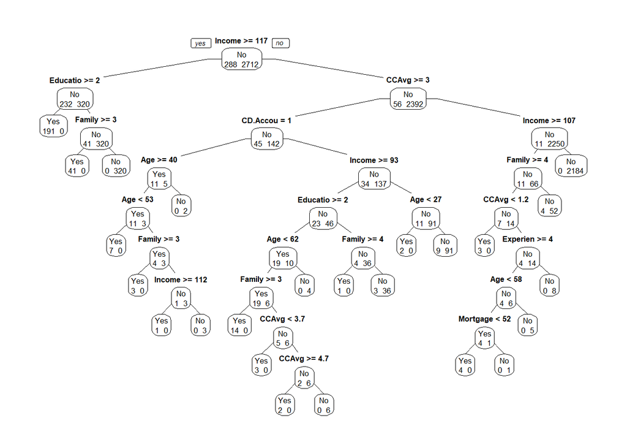

```r
full.tree.prune <- prune(full.tree.rpart, cp = cpmin)

prp(full.tree.prune, type = 1, extra = 1)
```

### Classification Tree using `caret`

The `caret` package can be used to make some improvements to the contruction of classification trees. First, the above tree was sensitive to the particular sampling that we carried out. With a different sample, the splits could have happned at different points and even at different variables. Thus the above trees are rather unstable.

Secondly, by default, `rpart` does not do any tuning of parameters.

`caret` addresses these issues and also provides a wrapper for several other classification models. The default settings in `caret` is to resample the data 25 times using bootstrap sampling and then run the models with three values of the tuing parameter. For using the `rpart` method, this parameter is the `Cp`. It then chooses the Cp that provides the highest accuracy.

```r
tree.caret.def <- train(Loan ~ .,
                        data = train.df,
                        method = "rpart")
tree.caret.def
```

```
## CART
##
## 3000 samples
##   11 predictor
##    2 classes: 'Yes', 'No'
##
## No pre-processing
## Resampling: Bootstrapped (25 reps)
## Summary of sample sizes: 3000, 3000, 3000, 3000, 3000, 3000, ...
## Resampling results across tuning parameters:
##
##   cp          Accuracy   Kappa
##   0.01041667  0.9794260  0.8773285
##   0.14236111  0.9665876  0.7892776
##   0.33159722  0.9191583  0.2354523
##
## Accuracy was used to select the optimal model using the largest value.
## The final value used for the model was cp = 0.01041667.
```

As we can see in the output above, 25 samples were taken with replacement, three different values of Cp were tried and the value that increased the accuracy was chosen.

We can examine this tree.

```r
tree.caret.def$finalModel
```

```
## n= 3000
##
## node), split, n, loss, yval, (yprob)
##       * denotes terminal node
##
##  1) root 3000 288 No (0.09600000 0.90400000)
##    2) Income>=116.5 552 232 No (0.42028986 0.57971014)
##      4) Education>=1.5 191   0 Yes (1.00000000 0.00000000) *
##      5) Education< 1.5 361  41 No (0.11357341 0.88642659)
##       10) Family>=2.5 41   0 Yes (1.00000000 0.00000000) *
##       11) Family< 2.5 320   0 No (0.00000000 1.00000000) *
##    3) Income< 116.5 2448  56 No (0.02287582 0.97712418) *
```

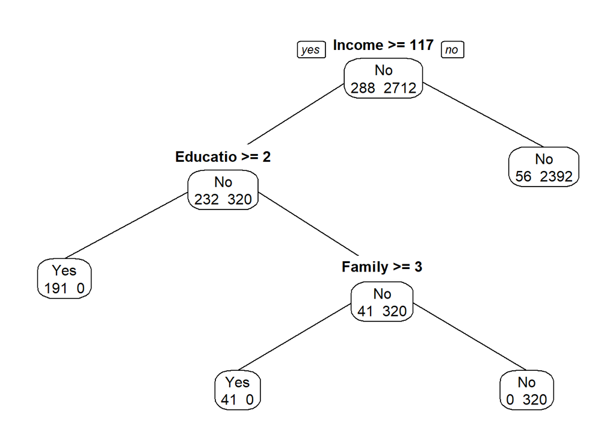

```r
prp(tree.caret.def$finalModel, type = 1, extra = 1)
```

Let us check it’s performance on the validation set.

```r
pred.Loan.def.val <- predict(tree.caret.def, newdata = valid.df)
confusionMatrix(pred.Loan.def.val,
                valid.df$Loan)
```

```
## Confusion Matrix and Statistics
##
##           Reference
## Prediction  Yes   No
##        Yes  149    0
##        No    43 1808
##
##                Accuracy : 0.9785
##                  95% CI : (0.9711, 0.9844)
##     No Information Rate : 0.904
##     P-Value [Acc > NIR] : < 2.2e-16
##
##                   Kappa : 0.8624
##
##  Mcnemar's Test P-Value : 1.504e-10
##
##             Sensitivity : 0.7760
##             Specificity : 1.0000
##          Pos Pred Value : 1.0000
##          Neg Pred Value : 0.9768
##              Prevalence : 0.0960
##          Detection Rate : 0.0745
##    Detection Prevalence : 0.0745
##       Balanced Accuracy : 0.8880
##
##        'Positive' Class : Yes
##
```

We could also tune over the depth of the tree by using the `maxdepth` argument in `method = "rpart2"`call.

```r
tree.caret.def2 <- train(Loan ~ .,
                        data = train.df,
                        method = "rpart2",
                        tuneLength = 15) #The default is to choose over 3 sizes.
```

```
## note: only 5 possible values of the max tree depth from the initial fit.
##  Truncating the grid to 5 .
```

```r
# we changed it to 15.
tree.caret.def2
```

```
## CART
##
## 3000 samples
##   11 predictor
##    2 classes: 'Yes', 'No'
##
## No pre-processing
## Resampling: Bootstrapped (25 reps)
## Summary of sample sizes: 3000, 3000, 3000, 3000, 3000, 3000, ...
## Resampling results across tuning parameters:
##
##   maxdepth  Accuracy   Kappa
##    2        0.9610389  0.7523551
##    3        0.9750342  0.8504105
##    7        0.9814539  0.8894173
##    8        0.9813448  0.8889660
##   11        0.9812361  0.8882263
##
## Accuracy was used to select the optimal model using the largest value.
## The final value used for the model was maxdepth = 7.
```

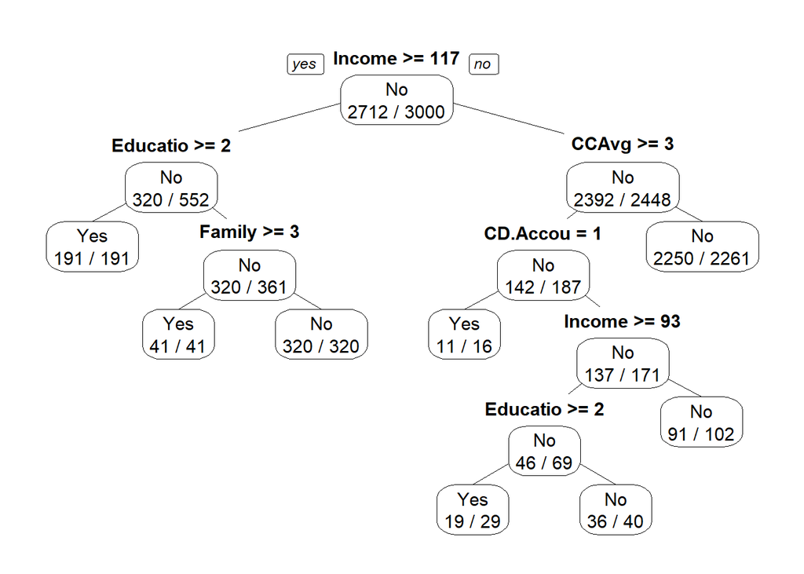

```r
prp(tree.caret.def2$finalModel, type = 1, extra = 2)
```

Note: the above is the same as the default tree by `rpart`.

One drawback however is that these trees depend on the initial random split of the sample and may be different if another sample was chosen. All the above trees are thus unstable.

Instability can be avoided by slicing the training set into a model building set and a holdout sample, building the model on the available data, check accuracy on the holdout sample and then repeat the process k times. This is called k-fold cross validation. This can then be repeated n times. `caret` makes it rather easy to implement this.

Another modification we will do is to tune the model using the ROC metric, rather than accuracy. Finally, we will search over 10 values of Cp.

```r
cntrl <- trainControl(method = "repeatedcv", number = 10, repeats = 3,
                      classProbs = T,
                      summaryFunction = twoClassSummary)

tree.caret.cv <- train(Loan ~ . ,
                       data = train.df,
                       method = "rpart",
                       trControl = cntrl,
                       tuneLength = 10,
                       #Use the ROC metric
                       metric = "ROC"
                       )

tree.caret.cv
```

```
## CART
##
## 3000 samples
##   11 predictor
##    2 classes: 'Yes', 'No'
##
## No pre-processing
## Resampling: Cross-Validated (10 fold, repeated 3 times)
## Summary of sample sizes: 2700, 2700, 2700, 2700, 2699, 2700, ...
## Resampling results across tuning parameters:
##
##   cp          ROC        Sens       Spec
##   0.00000000  0.9821120  0.8645731  0.9939793
##   0.03684414  0.9074543  0.7859606  0.9993850
##   0.07368827  0.9061081  0.7906404  0.9969263
##   0.11053241  0.9061081  0.7906404  0.9969263
##   0.14737654  0.8765320  0.6540230  0.9972953
##   0.18422068  0.8727045  0.6471264  0.9975413
##   0.22106481  0.8727045  0.6471264  0.9975413
##   0.25790895  0.8727045  0.6471264  0.9975413
##   0.29475309  0.8032378  0.5169951  0.9991390
##   0.33159722  0.6209921  0.1961002  1.0000000
##
## ROC was used to select the optimal model using the largest value.
## The final value used for the model was cp = 0.
```

```r
tree.caret.cv$finalModel
```

```
## n= 3000
##
## node), split, n, loss, yval, (yprob)
##       * denotes terminal node
##
##   1) root 3000 288 No (0.096000000 0.904000000)
##     2) Income>=116.5 552 232 No (0.420289855 0.579710145)
##       4) Education>=1.5 191   0 Yes (1.000000000 0.000000000) *
##       5) Education< 1.5 361  41 No (0.113573407 0.886426593)
##        10) Family>=2.5 41   0 Yes (1.000000000 0.000000000) *
##        11) Family< 2.5 320   0 No (0.000000000 1.000000000) *
##     3) Income< 116.5 2448  56 No (0.022875817 0.977124183)
##       6) CCAvg>=2.95 187  45 No (0.240641711 0.759358289)
##        12) CD.Account>=0.5 16   5 Yes (0.687500000 0.312500000) *
##        13) CD.Account< 0.5 171  34 No (0.198830409 0.801169591)
##          26) Income>=92.5 69  23 No (0.333333333 0.666666667)
##            52) Education>=1.5 29  10 Yes (0.655172414 0.344827586)
##             104) Family>=2.5 18   4 Yes (0.777777778 0.222222222) *
##             105) Family< 2.5 11   5 No (0.454545455 0.545454545) *
##            53) Education< 1.5 40   4 No (0.100000000 0.900000000) *
##          27) Income< 92.5 102  11 No (0.107843137 0.892156863) *
##       7) CCAvg< 2.95 2261  11 No (0.004865104 0.995134896)
##        14) Income>=106.5 77  11 No (0.142857143 0.857142857)
##          28) Family>=3.5 21   7 No (0.333333333 0.666666667)
##            56) Experience>=3.5 13   6 Yes (0.538461538 0.461538462) *
##            57) Experience< 3.5 8   0 No (0.000000000 1.000000000) *
##          29) Family< 3.5 56   4 No (0.071428571 0.928571429) *
##        15) Income< 106.5 2184   0 No (0.000000000 1.000000000) *
```

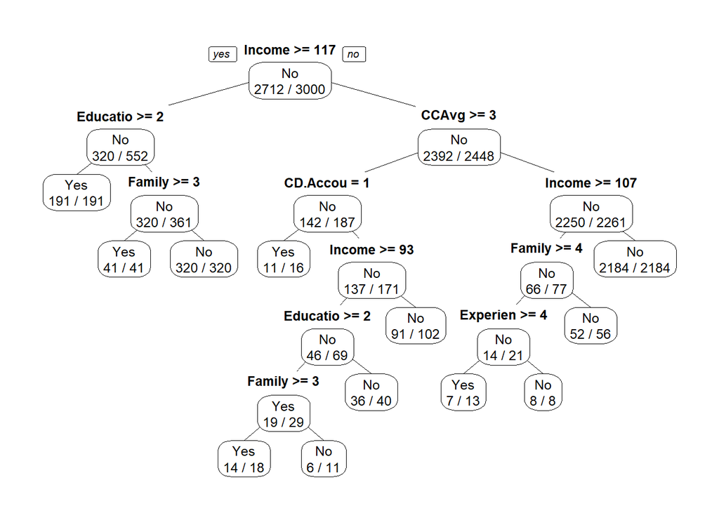

```r
prp(tree.caret.cv$finalModel, type = 1, extra  = 2)
```

This is still a pretty extensive tree. We can get the best pruned tree using the argument: `method = rpart1SE`

```r
cntrl <- trainControl(method = "repeatedcv", number = 10, repeats = 3,
                      classProbs = T,
                      summaryFunction = twoClassSummary)

tree.caret.cv <- train(Loan ~ . ,
                       data = train.df,
                       method = "rpart1SE",
                       trControl = cntrl,
                        tuneLength = 10,
                       #Use the ROC metric
                       metric = "ROC"
                       )

tree.caret.cv
```

```
## CART
##
## 3000 samples
##   11 predictor
##    2 classes: 'Yes', 'No'
##
## No pre-processing
## Resampling: Cross-Validated (10 fold, repeated 3 times)
## Summary of sample sizes: 2700, 2700, 2699, 2700, 2701, 2701, ...
## Resampling results:
##
##   ROC        Sens       Spec
##   0.9564317  0.8367816  0.9955738
```

```r
tree.caret.cv$finalModel
```

```
## n= 3000
##
## node), split, n, loss, yval, (yprob)
##       * denotes terminal node
##
##  1) root 3000 288 No (0.096000000 0.904000000)
##    2) Income>=116.5 552 232 No (0.420289855 0.579710145)
##      4) Education>=1.5 191   0 Yes (1.000000000 0.000000000) *
##      5) Education< 1.5 361  41 No (0.113573407 0.886426593)
##       10) Family>=2.5 41   0 Yes (1.000000000 0.000000000) *
##       11) Family< 2.5 320   0 No (0.000000000 1.000000000) *
##    3) Income< 116.5 2448  56 No (0.022875817 0.977124183)
##      6) CCAvg>=2.95 187  45 No (0.240641711 0.759358289)
##       12) CD.Account>=0.5 16   5 Yes (0.687500000 0.312500000) *
##       13) CD.Account< 0.5 171  34 No (0.198830409 0.801169591)
##         26) Income>=92.5 69  23 No (0.333333333 0.666666667)
##           52) Education>=1.5 29  10 Yes (0.655172414 0.344827586) *
##           53) Education< 1.5 40   4 No (0.100000000 0.900000000) *
##         27) Income< 92.5 102  11 No (0.107843137 0.892156863) *
##      7) CCAvg< 2.95 2261  11 No (0.004865104 0.995134896) *
```

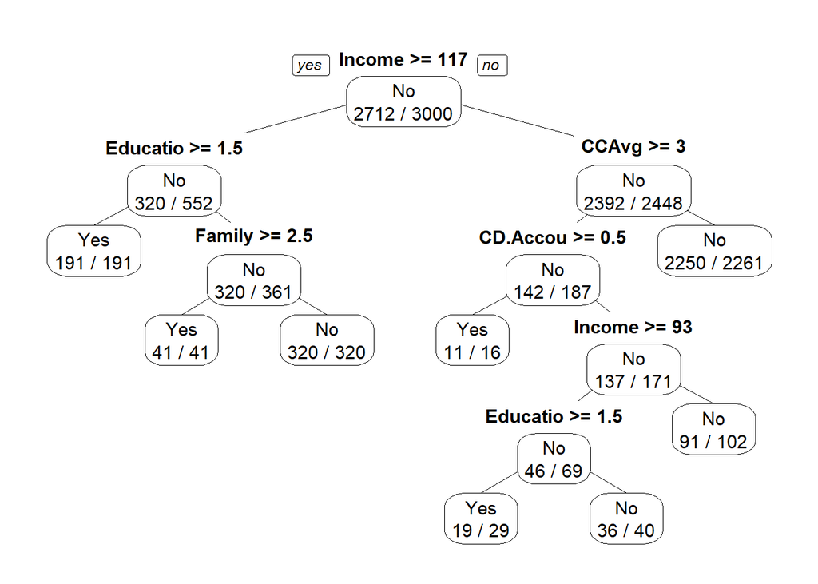

```r
prp(tree.caret.cv$finalModel, type = 1, extra  = 2)
```

Or, we can stay with the default tree from caret

```r
cntrl <- trainControl(method = "repeatedcv", number = 10, repeats = 3,
                      classProbs = T,
                      summaryFunction = twoClassSummary)
set.seed(1089)
tree.caret.def.cv <- train(Loan ~ . ,
                       data = train.df,
                       method = "rpart1SE",
                       trControl = cntrl,
                      # tuneLength = 10,
                       #Use the ROC metric
                       metric = "ROC"
                       )

tree.caret.def.cv
```

```
## CART
##
## 3000 samples
##   11 predictor
##    2 classes: 'Yes', 'No'
##
## No pre-processing
## Resampling: Cross-Validated (10 fold, repeated 3 times)
## Summary of sample sizes: 2699, 2700, 2700, 2701, 2700, 2700, ...
## Resampling results:
##
##   ROC      Sens       Spec
##   0.95811  0.8428571  0.9955733
```

```r
tree.caret.def.cv$finalModel
```

```
## n= 3000
##
## node), split, n, loss, yval, (yprob)
##       * denotes terminal node
##
##  1) root 3000 288 No (0.096000000 0.904000000)
##    2) Income>=116.5 552 232 No (0.420289855 0.579710145)
##      4) Education>=1.5 191   0 Yes (1.000000000 0.000000000) *
##      5) Education< 1.5 361  41 No (0.113573407 0.886426593)
##       10) Family>=2.5 41   0 Yes (1.000000000 0.000000000) *
##       11) Family< 2.5 320   0 No (0.000000000 1.000000000) *
##    3) Income< 116.5 2448  56 No (0.022875817 0.977124183)
##      6) CCAvg>=2.95 187  45 No (0.240641711 0.759358289)
##       12) CD.Account>=0.5 16   5 Yes (0.687500000 0.312500000) *
##       13) CD.Account< 0.5 171  34 No (0.198830409 0.801169591)
##         26) Income>=92.5 69  23 No (0.333333333 0.666666667)
##           52) Education>=1.5 29  10 Yes (0.655172414 0.344827586) *
##           53) Education< 1.5 40   4 No (0.100000000 0.900000000) *
##         27) Income< 92.5 102  11 No (0.107843137 0.892156863) *
##      7) CCAvg< 2.95 2261  11 No (0.004865104 0.995134896) *
```

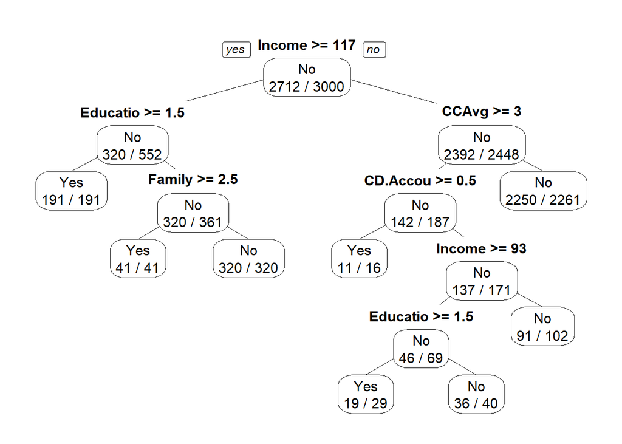

```r
prp(tree.caret.def.cv$finalModel, type = 1, extra  = 2, roundint=FALSE)
```

Let us next get the ROC and AUC information. For the `roc` curve, the function expects probabilities of the predicted class.

```r
library(pROC)
pred.class <- predict(tree.caret.def.cv, newdata = valid.df)

head(pred.class)
```

```
## [1] No  No  No  No  No  Yes
## Levels: Yes No
```

```r
pred.class.prob <- predict(tree.caret.def.cv, newdata = valid.df, type = "prob")
head(pred.class.prob) # Note: This produces a dataframe
```

```
##            Yes        No
## 2  0.004865104 0.9951349
## 5  0.004865104 0.9951349
## 6  0.004865104 0.9951349
## 8  0.004865104 0.9951349
## 11 0.004865104 0.9951349
## 13 0.655172414 0.3448276
```

```r
confusionMatrix(pred.class, valid.df$Loan)
```

```
## Confusion Matrix and Statistics
##
##           Reference
## Prediction  Yes   No
##        Yes  176    7
##        No    16 1801
##
##                Accuracy : 0.9885
##                  95% CI : (0.9828, 0.9927)
##     No Information Rate : 0.904
##     P-Value [Acc > NIR] : < 2e-16
##
##                   Kappa : 0.9323
##
##  Mcnemar's Test P-Value : 0.09529
##
##             Sensitivity : 0.9167
##             Specificity : 0.9961
##          Pos Pred Value : 0.9617
##          Neg Pred Value : 0.9912
##              Prevalence : 0.0960
##          Detection Rate : 0.0880
##    Detection Prevalence : 0.0915
##       Balanced Accuracy : 0.9564
##
##        'Positive' Class : Yes
##
```

```r
### roc considers the first level as control and the second level as the target
### thus we need to relevel the outcome variable

roc.cart1 <- roc(response = valid.df$Loan,
               predictor = pred.class.prob$Yes,
               levels = rev(levels(valid.df$Loan)),
               plot = F, add = TRUE)
auc(roc.cart1)
```

```
## Area under the curve: 0.9792
```

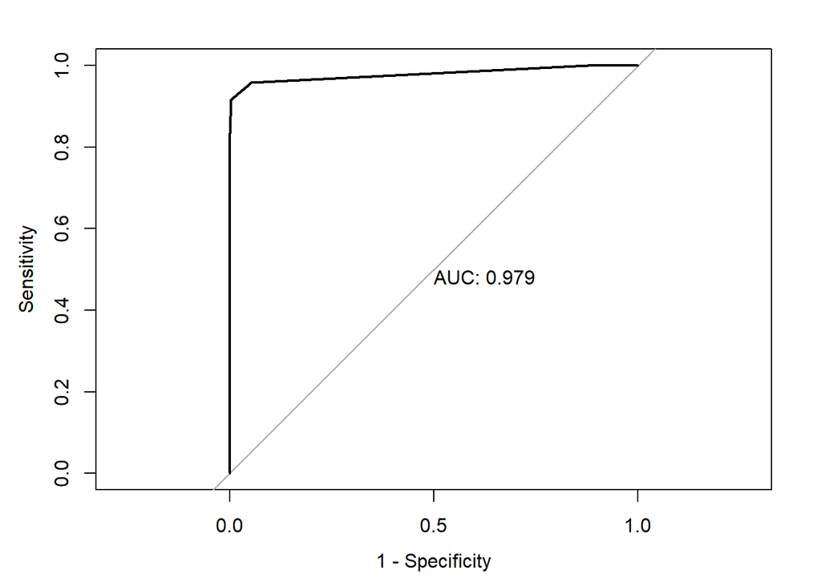

```r
plot(roc.cart1, legacy.axes = T, print.auc = T)
```

We can also plot the lift charts. Note that we need to get the actual class and predicted probability in the same dataframe for `lift_curve()` in `yardstick` package.

```r
lift.data1 <- cbind(data.frame(truth = valid.df$Loan),
                    data.frame(rpart.class =pred.class.prob$Yes))

library(yardstick)
```

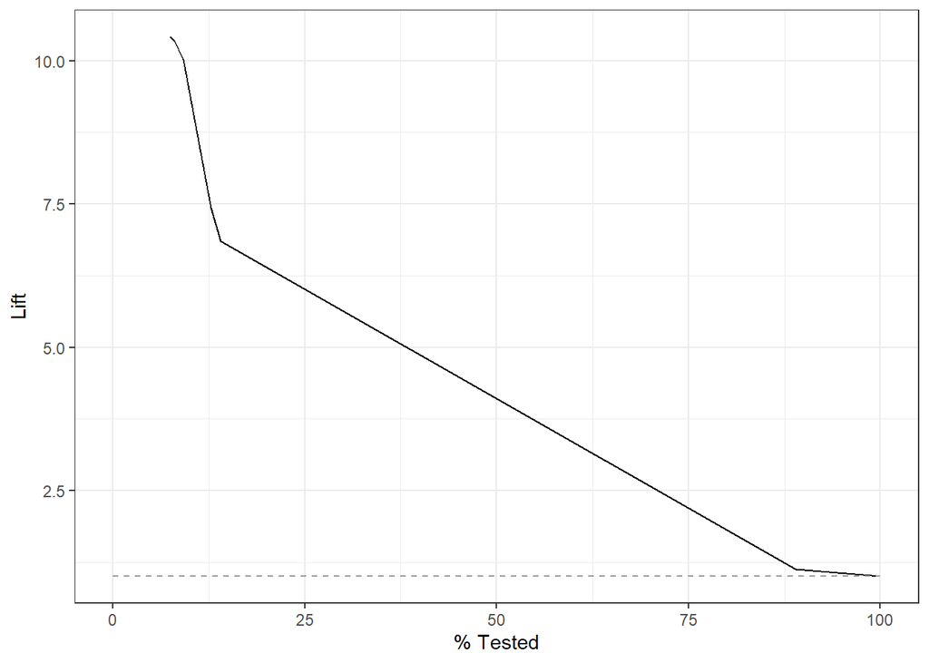

```r
rpart.lift <- lift_curve(lift.data1, truth, rpart.class)
autoplot(rpart.lift)
```